# Univariate Simulation

28 Sep 2016

## Univariate sampling

We will consider algorithms for sampling observations from a distribution on \(\mathbb{R}\).

There can be several purposes:

- We want to investigate properties of the distribution.
- We want to simulate independent realizations of univariate random variables to investigate the distribution of a transformation.
- We want to use Monte Carlo integration to compute numerically an integral (which could be a probability).

## Transformation methods

If \(T : \mathcal{Z} \to \mathbb{R}\) is a map and \(Z \in \mathcal{Z}\) is a random variable we can sample, then we can sample \(X = T(Z).\)

**Classical example:** If \(F^{\leftarrow} : (0,1) \mapsto \mathbb{R}\) is the (generalized) inverse of a distribution function and \(U\) is uniformly distributed on \((0, 1)\) then  
\[F^{\leftarrow}(U)\] has distribution function \(F\).

This is how R generates samples from \(\mathcal{N}(0,1)\) using a technical approximation of \(\Phi^{-1}\) based on rational functions.

## Pseudo random numbers

Most sampling algorithms are based on algorithms for generating *pseudo random* uniformly distributed samples on \((0, 1)\). They arise from deterministic integer sequences initiated by a *seed*.

In R you can get the same sequence by setting the seed.

```r
set.seed(27112015)
oldseed <- head(.Random.seed, 10)
tmp <- runif(1)
tmp
```

```
[1] 0.7793288
```

## Pseudo random numbers

```r
oldseed
```

```
 [1]         403         624 -1660633125 -1167670944  1031453153
 [6]   815285806  -340883241   546144044 -1074785731  -160910374
```

```r
head(.Random.seed, 10)
```

```
 [1]         403           1  -696993996 -1035426662  -378189083
 [6]  -745352065 -1401016826  -323987056   983360563   297855953
```

```r
c(tmp, runif(1))
```

```
[1] 0.7793288 0.5613179
```

## Pseudo random numbers

```r
set.seed(27112015)
head(.Random.seed, 10)
```

```
 [1]         403         624 -1660633125 -1167670944  1031453153
 [6]   815285806  -340883241   546144044 -1074785731  -160910374
```

```r
oldseed  ## Same as current .Random.seed
```

```
 [1]         403         624 -1660633125 -1167670944  1031453153
 [6]   815285806  -340883241   546144044 -1074785731  -160910374
```

```r
runif(1) ## Same as tmp
```

```
[1] 0.7793288
```

## Pseudo random numbers

It is a research field to develop pseudo random number generators, see `?RNG` in R for the algorithms available.

The R default (v. 3.2.2) is the 32-bit *Mersenne Twister*, which generates integers in the range \[\{0, 1, \ldots, 2^{32} -1\}.\] It has a long period and all combinations of consecutive integers up to dimension 623 occur equally often in a period. It has good statistical properties.

Pseudo random numbers in \((0, 1)\) are returned by `runif` by division with \(2^{32}\) and a fix to prevent the algorithm from returning 0.

## Sampling from a \(t\)-distribution

Let \(Z = (Y, W) \in \mathbb{R} \times (0, \infty)\) with \(Z \sim \mathcal{N}(0, 1)\) and \(W \sim \chi^2_k\) independent.

Define \(T : \mathbb{R} \times (0, \infty) \to \mathbb{R}\) by \[T(z,w) = \frac{z}{\sqrt{w/k}},\]

then \[X = T(Z, W) = \frac{Z}{\sqrt{W/k}} \sim t_k.\]

This is how R simulates from a \(t\)-distribution with \(W\) generated from a Gamma distribution with shape parameter \(k / 2\) and scale parameter \(2\).

## Rejection sampling

Let \(Y_1, Y_2, \ldots\) be i.i.d. with density \(g\) on \(\mathbb{R}\) and \(U_1, U_2, \ldots\) be i.i.d. uniform and independent of the \(Y_i\)s. Define \[T(\mathbf{Y}, \mathbf{U}) = Y_{\sigma}\] with \[\sigma = \inf\{n \geq 1 \mid U_n \leq \alpha f(Y_n) / g(Y_n)\},\] for \(\alpha \in (0, 1]\) and \(f\) a density.

**Theorem:** If \(\alpha f(y) \leq g(y)\) for all \(y \in \mathbb{R}\) then the distribution of \(Y_{\sigma}\) has density \(f\).

## Rejection sampling

The formal proof decomposes the event \((Y_{\sigma} \leq y)\) according to the value of \(\sigma\) to reduce the computation to the one on page 155,

\[ \begin{aligned} P(Y_{\sigma} \leq y) & = \sum_{n = 1}^{\infty} P(Y_{n} \leq y, \sigma = k) \\ & = \sum_{n = 1}^{\infty} P(Y_{n} \leq y, U_n \leq \alpha f(Y_n) / g(Y_n)) P(\sigma > n - 1) \\ & = \ldots \\ & = \int_{-\infty}^y f(z) \mathrm{d} z. \end{aligned} \]

Note that \(\alpha f \leq g\) for densities \(f\) and \(g\) implies that \(\alpha \leq 1\).

## Normalizing constants

If \(f(x) = c q(x)\) and \(g(x) = d p(x)\) for (unknown) normalizing constants \(c, d > 0\) and \(\alpha' q \leq p\) then  
\[\underbrace{\left(\frac{\alpha' d}{c}\right)}_{= \alpha} \ f \leq g.\]

Moreover, \[u \leq \frac{\alpha f(y)}{g(y)} \Leftrightarrow u \leq \frac{\alpha' q(y)}{p(y)},\] and rejection sampling can be implemented without computing \(c\) or \(d\).

## Gamma distribution

Can we find a suitable envelope? Perhaps, but it turns out to be smarter to use rejection sampling of a non-standard distribution and transform it by a simple transformation.

Let \(t(y) = a(1 + by)^3\) for \(y \in (-b^{-1}, \infty)\), then \(t(Y) \sim \Gamma(r,1)\) if \(Y\) has density \[f(y) \propto t(y)^{r-1}t'(y) e^{-t(y)} = e^{(r-1)\log t(y) + \log t'(y) - t(y)}.\]

[Proof: Use univariate density transformation theorem.]

The density \(f\) will be the *target density* for a rejection sampler.

## Gamma distribution

With \[f(y) \propto e^{(r-1)\log t(y) + \log t'(y) - t(y)},\] \(a = r - 1/3\) and \(b = 1/(3 \sqrt{a})\) \[f(y) \propto e^{a \log t(y)/a - t(y) + a \log a} \propto \underbrace{e^{a \log t(y)/a - t(y) + a}}_{q(y)}.\]

An analysis of \(w(y) := - y^2/2 - \log q(y)\) shows that it is convex on \((-b^{-1}, \infty)\) and it attains its minimum in 0 with \(w(0) = 0\), whence \[q(y) \leq e^{-y^2/2}.\]

## Gamma distribution

```r
## r >= 1
tfun <- function(y, a) {
  b <- 1 / (3 * sqrt(a))
  (y > -1/b) * a * (1 + b * y)^3  ## 0 when y <= -1/b
}
```

```r
qfun <- function(y, r) {
  a <- r - 1/3
  tval <- tfun(y, a)
  exp(a * log(tval / a) - tval + a)
}
```

## Gamma distribution

```r
gammasim <- function(n, r) {
  y <- numeric(n)
  for(i in 1:n) {
    ratio <- 0
    u <- 1
    while(u > ratio) {
      y0 <- rnorm(1)
      ratio <- qfun(y0, r) * exp(y0^2/2)
      u <- runif(1)
    }
    y[i] <- y0
  }
  tfun(y, r - 1/3)
}
```

## Gamma distribution

```r
system.time(tmp <- gammasim(10000, 8))
```

```
   user  system elapsed
  0.140   0.006   0.147
```

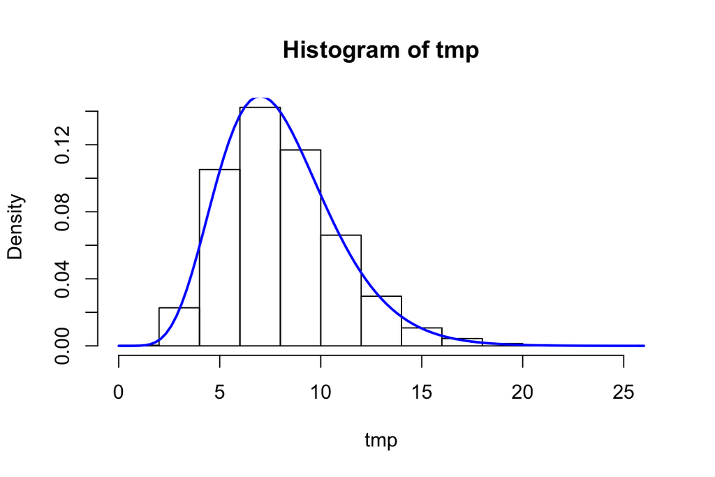

## Gamma distribution

```r
system.time(tmp <- gammasim(10000, 1))
```

```
   user  system elapsed
  0.139   0.002   0.141
```

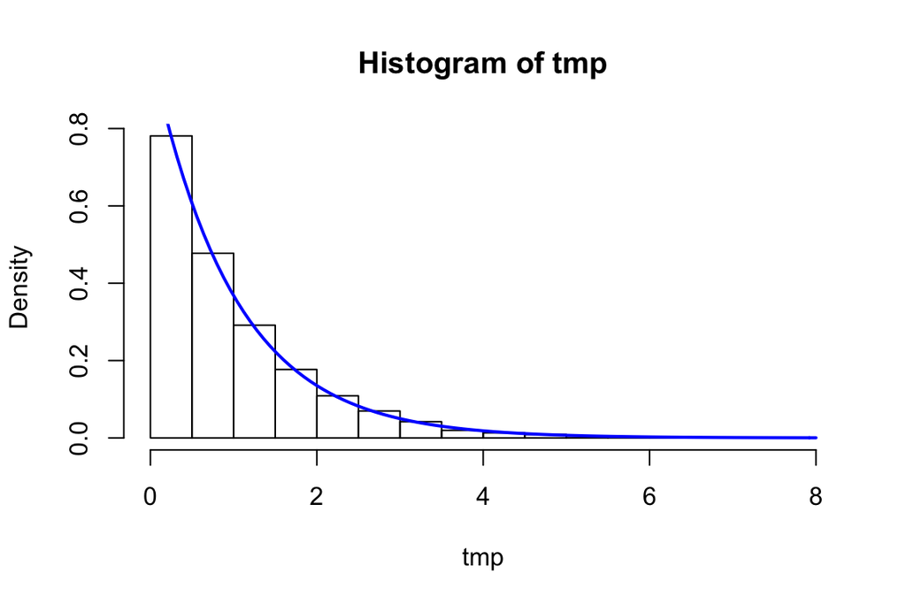

## The \(f \propto q\) density

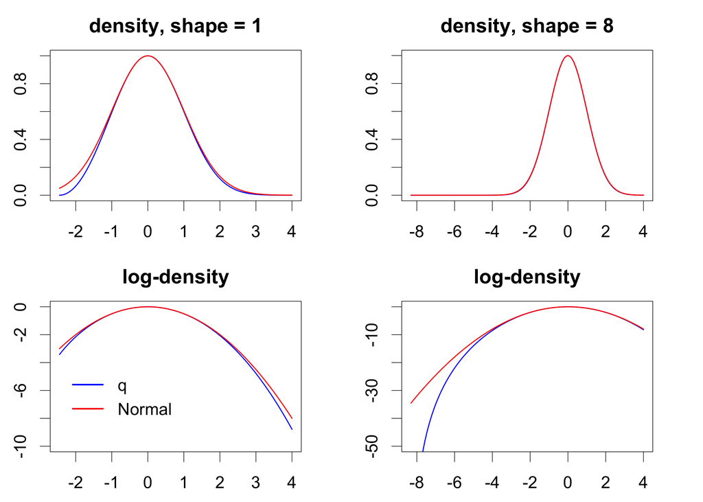

## Monte Carlo integration

A typical usage of sampling is Monte Carlo integration.

With \(X_1, \ldots, X_n\) i.i.d. with density \(f\) \[\hat{\mu}_{\textrm{MC}} := \frac{1}{n} \sum_{i=1}^n h(X_i) \rightarrow \mu := \mathbb{E} h(X_1) = \int h(x) f(x) \ dx\] for \(n \to \infty\) by the law of large numbers (LLN).

## Monte Carlo integration

The CLT gives that \[\frac{1}{n} \sum_{i=1}^n h(X_i) \overset{\textrm{approx}} \sim \mathcal{N}(\mu, \sigma^2_{\textrm{MC}} / n)\]

where \[\sigma^2_{\textrm{MC}} = \mathbb{V} h(X_1) = \int (h(x) - \mu)^2 f(x) \ dx.\]

## Monte Carlo integration

We can estimate \(\sigma^2_{\textrm{MC}}\) using the empirical variance \[\hat{\sigma}^2_{\textrm{MC}} = \frac{1}{n - 1} \sum_{i=1}^n (h(X_i) - \hat{\mu}_{\textrm{MC}})^2,\]

then the variance of \(\hat{\mu}_{\textrm{MC}}\) is estimated as \(\hat{\sigma}^2_{\textrm{MC}} / n\) and a standard 95% confidence interval for \(\mu\) is \[\hat{\mu}_{\textrm{MC}} \pm 1.96 \frac{\hat{\sigma}_{\textrm{MC}}}{\sqrt{n}}.\]

## Importance sampling

When we are only interested in Monte Carlo integration, we do not need to sample from the target distribution.

Observe that \[ \begin{aligned} \mu = \int h(x) f(x) \ dx & = \int h(x) \frac{f(x)}{g(x)} g(x) \ dx \\ & = \int h(x) w^*(x) g(x) \ dx \end{aligned} \] whenever \(g\) is a density fulfilling that \[g(x) = 0 \Rightarrow f(x) = 0.\]

## Importance sampling

With \(X_1, \ldots, X_n\) i.i.d. with density \(g\) define the *weights* \[w^*(X_i) = f(X_i) / g(X_i).\]

The *importance sampling* estimator is \[\hat{\mu}_{\textrm{IS}}^* := \frac{1}{n} \sum_{i=1}^n h(X_i)w^*(X_i).\]

It has mean \(\mu\).

## Importance sampling variance

Again by the LLN \[\hat{\mu}_{\textrm{IS}}^* \rightarrow \mathbb{E} h(X_1) w^*(X_1) = \mu,\]

and by the CLT \[\hat{\mu}_{\textrm{IS}}^* \overset{\textrm{approx}} \sim \mathcal{N}(\mu, \sigma^{*2}_{\textrm{IS}} / n)\]

where \[\sigma^{*2}_{\textrm{IS}} = \mathbb{V} h(X_1)w^*(X_1) = \int (h(x) w^*(x) - \mu)^2 g(x) \ dx.\]

## Importance sampling variance

We may have \(\sigma^{*2}_{\textrm{IS}} > \sigma^2_{\textrm{MC}}\) or \(\sigma^{*2}_{\textrm{IS}} < \sigma^2_{\textrm{MC}}\) depending on \(h\) and \(g\).

By choosing \(g\) cleverly so that \(h(x) w^*(x)\) becomes as constant as possible, importance sampling can reduce the variance considerably compared to standard MC.

## Importance sampling variance

The importance sampling variance can be estimated just as the MC variance \[\hat{\sigma}^{*2}_{\textrm{IS}} = \frac{1}{n - 1} \sum_{i=1}^n (h(X_i)w^*(X_i) - \hat{\mu}_{\textrm{IS}}^*)^2,\]

and a 95% standard confidence interval is \[\hat{\mu}^*_{\textrm{IS}} \pm 1.96 \frac{\hat{\sigma}^*_{\textrm{IS}}}{\sqrt{n}}.\]

## Standardized weights

If \(f = c^{-1} q\) with \(c\) unknown then \[c = \int q(x) \ dx = \int \frac{q(x)}{g(x)} g(x) \ d x,\]

and \[\mu = \frac{\int h(x) w^*(x) g(x) \ d x}{\int w^*(x) g(x) \ d x},\] where \(w^*(x) = q(x) / g(x).\)

## IS with standardized weights

An importance sampling estimate of \(\mu\) is thus \[\hat{\mu}_{\textrm{IS}} = \frac{\sum_{i=1}^n h(X_i) w^*(X_i)}{\sum_{i=1}^n w^*(X_i)} = \sum_{i=1}^n h(X_i) w(X_i),\] where \(w^*(X_i) = q(X_i) / g(X_i)\) and \[w(X_i) = \frac{w^*(X_i)}{\sum_{i=1}^n w^*(X_i)}\] are the *standardized weights*.

This works irrespectively of the value of the normalizing constant \(c\).

## Importance sampling variance

The variance of the IS estimator with standardized weights is a little more complicated, because the estimator is a ratio of random variables.

From the multivariate CLT

\[ \frac{1}{n} \sum_{i=1}^n \left(\begin{array}{c} h(X_i) w^*(X_i) \\ w^*(X_i) \end{array}\right) \overset{\textrm{approx}}{\sim} \mathcal{N}\left( c \left(\begin{array}{c} \mu \\ 1 \end{array}\right), \frac{1}{n} \left(\begin{array}{cc} \sigma^{*2}_{\textrm{IS}} & \gamma \\ \gamma & \sigma^2_{w^*} \end{array} \right)\right), \]

where \[ \begin{aligned} \sigma^{*2}_{\textrm{IS}} & = \mathbb{V} h(X_1)w^*(X_1) \\ \gamma & = \mathrm{cov}(h(X_1)w^*(X_1), w^*(X_1)) \\ \sigma_{w^*}^2 & = \mathbb{V} w^*(X_1). \end{aligned} \]

## Importance sampling variance

We can then apply the \(\Delta\)-method with \(h(x, y) = x / y\).

Observe that \(Dh(x, y) = (1 / y, - x / y^2)\), whence

\[ Dh(c\mu, c) \left(\begin{array}{cc} \hat{\sigma}^{*2}_{\textrm{IS}} & \gamma \\ \gamma & \sigma^2_{w^*} \end{array} \right) Dh(c\mu, c)^T = c^{-2} (\sigma^{*2}_{\textrm{IS}} + \mu^2 \sigma_{w^*}^2 - 2 \mu \gamma). \]

By the \(\Delta\)-method \[\hat{\mu}_{\textrm{IS}} \overset{\textrm{approx}}{\sim} \mathcal{N}(\mu, c^{-2} (\sigma^{*2}_{\textrm{IS}} + \mu^2 \sigma_{w^*}^2 - 2 \mu \gamma) / n).\]

For \(c = 1\), the asymptotic variance equals the first term in (6.43) on page 182, and it can be estimated by plugging in empirical estimates. For \(c \neq 1\) it is necessary to estimate \(c\) as \(\hat{c} = \frac{1}{n} \sum_{i=1}^n w^*(X_i)\).

## Example 6.9

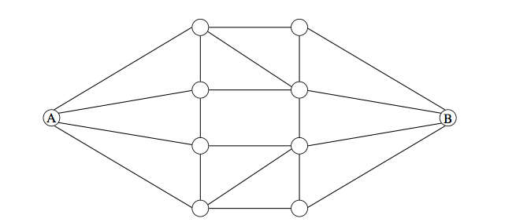

The different edges "fail" independently with probability \(p\).

What is the probability that A and B are disconnected?

## Representing graphs

```r
A  ## Graph adjacency matrix
```

```
      [,1] [,2] [,3] [,4] [,5] [,6] [,7] [,8] [,9] [,10]
 [1,]    0    1    1    1    1    0    0    0    0     0
 [2,]    1    0    1    0    0    1    1    0    0     0
 [3,]    1    1    0    1    0    0    1    0    0     0
 [4,]    1    0    1    0    1    0    0    1    0     0
 [5,]    1    0    0    1    0    0    0    1    1     0
 [6,]    0    1    0    0    0    0    1    0    0     1
 [7,]    0    1    1    0    0    1    0    1    0     1
 [8,]    0    0    0    1    1    0    1    0    1     1
 [9,]    0    0    0    0    1    0    0    1    0     1
[10,]    0    0    0    0    0    1    1    1    1     0
```

## Sampling a graph

```r
simNet <- function(Aup, p) {
  ones <- which(Aup == 1)
  Aup[ones] <- sample(c(0, 1), length(ones),
                      replace = TRUE, prob = c(p, 1 - p))
  Aup + t(Aup)
}
```

```r
Aup <- A
Aup[lower.tri(Aup)] <- 0
system.time(replicate(1e5, {simNet(Aup, 0.5); NULL}))
```

```
   user  system elapsed
  2.133   0.064   2.200
```

## Check connectivity

```r
disconAB <- function(A) {
  i <- 3
  Apow <- A %*% A %*% A ## A%^%3
  while(Apow[1, 10] == 0 & i < 9) {
    Apow <- Apow %*% A
    i <- i + 1
  }
  Apow[1, 10] == 0  ## TRUE if A and B not connected
}
```

## Estimating probability of A and B disconnected

```r
set.seed(27092016)
n <- 1e6
tmp <- replicate(n, disconAB(simNet(Aup, 0.05)))
muhat <- mean(tmp)
```

Estimate with confidence interval using \(\sigma^2 = \mu (1 - \mu)\).

```r
muhat + 1.96 * sqrt(muhat * (1 - muhat) / n) * c(-1, 0, 1)
```

```
[1] 5.210402e-06 1.200000e-05 1.878960e-05
```

## Importance sampling

```r
impw <- function(Aup, A0, p, p0) {
  w <- disconAB(A0)
  if (w) {
    b <- 20 - sum(Aup[A0 == 1])
    w <- ((1 - p0) / (1 - p))^20 *
      (p0 * (1 - p) / (p * (1 - p0)))^b
  }
  as.numeric(w)
}
```

This uses formula (6.48) in the book for computing the importance weights. For the IS estimator they are multiplied by the indicator that A and B are disconnected.

## Estimating probability of A and B disconnected

```r
tmp <- replicate(n, impw(Aup, simNet(Aup, 0.2), 0.2, 0.05))
muhatIS <- mean(tmp)
```

Confidence interval using empirical variance estimate \(\hat{\sigma}^2\).

```r
muhatIS + 1.96 * sd(tmp) / sqrt(n) * c(-1, 0, 1)
```

```
[1] 1.172375e-05 1.293660e-05 1.414946e-05
```

```r
c(sd(tmp), sqrt(muhat * (1 - muhat))) ## The two standard deviations
```

```
[1] 0.000618803 0.003464081
```

## Comparison

The ratio of variances is estimated as

```r
muhat * (1 - muhat) / var(tmp)
```

```
[1] 31.33799
```

We need around 31 times more naive samples when compared to importance sampling to obtain the same precision.

A benchmark will show that the extra computing time for importance sampling is small compared to the reduction of variance.

It is worth the coding effort if used repeatedly, but not if it is a one-off computation.

## Enumeration

There are \(2^{20} = 1,048,576\) different networks with any number of the edges failing, so complete enumeration is possible.

```r
ones <- which(Aup == 1)
p <- 0.05
prob <- numeric(2^20)
for(i in 0:(2^20 - 1)) {
  on <- as.numeric(intToBits(i)[1:20])
  nr <- sum(on)
  Atmp <- Aup
  Atmp[ones] <- on
  if(disconAB(Atmp + t(Atmp)))
    prob[i + 1] <- p^(20 - nr) * (1 - p)^nr
}
```

## The probability of A and B disconnected

```r
sum(prob)
```

```
[1] 1.336707e-05
```

```r
muhat + 1.96 * sqrt(muhat * (1 - muhat) / n) * c(-1, 0, 1)
```

```
[1] 5.210402e-06 1.200000e-05 1.878960e-05
```

```r
muhatIS + 1.96 * sd(tmp) / sqrt(n) * c(-1, 0, 1)
```

```
[1] 1.172375e-05 1.293660e-05 1.414946e-05
```

## Object oriented implementation

```r
network <- function(A, p) {
  Aup <- A
  Aup[lower.tri(Aup)] <- 0
  ones <- which((Aup == 1))
  structure(list(A = A, Aup = Aup, ones = ones, p = p),
            class = "network")
}
myNet <- network(A, p = 0.05)
str(myNet)
```

```
List of 4
 $ A   : num [1:10, 1:10] 0 1 1 1 1 0 0 0 0 0 ...
 $ Aup : num [1:10, 1:10] 0 0 0 0 0 0 0 0 0 0 ...
 $ ones: int [1:20] 11 21 22 31 33 41 44 52 62 63 ...
 $ p   : num 0.05
 - attr(*, "class")= chr "network"
```

## Generic functions

```r
sim <- function(x, ...)
  UseMethod("sim")
failure <- function(x, ...)
  UseMethod("failure")
```

The first method

```r
sim.network <- function(x) {
  Aup <- x$Aup
  Aup[x$ones] <- sample(c(0, 1), length(x$ones),
                        replace = TRUE, prob = c(x$p, 1 - x$p))
  Aup + t(Aup)
}
```

## and the second method

```r
failure.network <- function(x, n, p = NULL) {
  if (is.null(p)) { ## Naive simulation
    tmp <- replicate(n, disconAB(sim(x)))
    muhat <- mean(tmp)
    se <- sqrt(muhat * (1 - muhat) / n)
  } else { ## Importance sampling
    p0 <- x$p
    x$p <- p
    tmp <- replicate(n, impw(x$Aup, sim(x), p, p0))
    se <- sd(tmp) / sqrt(n)
    muhat <- mean(tmp)
  }
  value <- muhat + 1.96 * se * c(-1, 0, 1)
  names(value) <- c("low", "estimate", "high")
  value
}
```

## Test

```r
set.seed(27092016)  ## Resetting seed
failure(myNet, n)
```

```
         low     estimate         high
5.210402e-06 1.200000e-05 1.878960e-05
```

```r
failure(myNet, n, p = 0.2)
```

```
         low     estimate         high
1.172375e-05 1.293660e-05 1.414946e-05
```

Check that the results are the same as on slide 40.

## Benchmarking

```r
system.time(replicate(1e5, {simNet(Aup, 0.5); NULL}))
```

```
   user  system elapsed
  2.023   0.105   2.129
```

```r
system.time(replicate(1e5, {sim(myNet); NULL}))
```

```
   user  system elapsed
  2.501   0.083   2.583
```

There is a small computational overhead due to method dispatching (the `sim` method).

## More methods

The generic `print` function already exists. We implement a method for class `network`.

```r
print.network <- function(x) {
  cat("#vertices: ", nrow(x$A), "\n")
  cat("#edges:", sum(x$Aup), "\n")
  cat("p = ", x$p, "\n")
}
```

```r
myNet  ## Implicitly calls 'print'
```

```
#vertices:  10
#edges: 20
p =  0.05
```

## Using igraph

```r
library(igraph)
net <- graph_from_adjacency_matrix(A, mode = "undirected")
net
```

```
IGRAPH U--- 10 20 --
+ edges:
 [1] 1-- 2 1-- 3 1-- 4 1-- 5 2-- 3 2-- 6 2-- 7 3-- 4 3-- 7 4-- 5 4-- 8
[12] 5-- 8 5-- 9 6-- 7 6--10 7-- 8 7--10 8-- 9 8--10 9--10
```

The igraph package supports a vast number of graph computation, manipulation and visualization tools.

## Plotting an igraph

```r
## You can generate a layout ...
net_layout <- layout_(net, nicely())
## ... or you can specify one yourself
net_layout <- matrix(
  c(-20,  0,
    -4,  3,
    -4,  1,
    -4, -1,
    -4, -3,
     4,  3,
     4,  1,
     4, -1,
     4, -3,
     20,  0),
  ncol = 2, nrow = 10, byrow = TRUE)
```

## Plotting an igraph

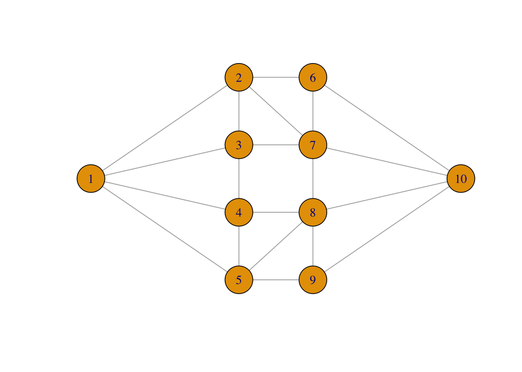

```r
plot(net, layout = net_layout, asp = 0)
```

## Simulation method for igraph

```r
sim.igraph <- function(x, p) {
  nr <- ecount(x)
  deledges <- sample(c(TRUE, FALSE), nr,
                     replace = TRUE, prob = c(p, 1 - p))
  delete_edges(x, which(deledges))
}
```

## A simulated graph

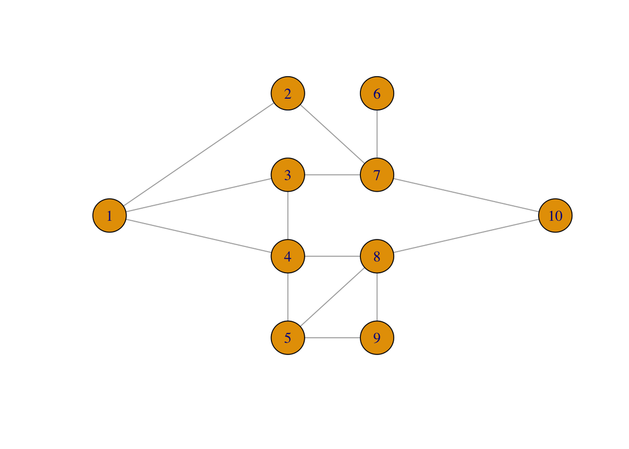

```r
plot(sim(net, 0.25), layout = net_layout, asp = 0)
```

## Simulation method for igraph

This is much slower than using the matrix representation alone as in `simNet`.

```r
system.time(replicate(1e5, {sim(net, 0.5); NULL}))
```

```
   user  system elapsed
 13.102   1.583  14.688
```

One could also implement the function for testing if A and B are disconnected using the `shortest_paths` function, but this is not faster than the simple matrix multiplications used in `disconAB` either, though it could be for larger graphs.